# The Hidden Barrier to Education: Lack of School Sanitation

- Show All Code
- Hide All Code

Author

Abshar Asker Abdullah

Published

April 27, 2025

# Introduction

Access to safe, clean sanitation in schools is essential for children’s health, dignity, and educational success. However, millions of children globally are still denied this basic necessity, particularly in low- and middle-income countries.

This report explores the global landscape of school sanitation availability, revealing inequalities across regions and income levels. Using UNICEF sanitation indicators and country-level development metrics, we analyze patterns, key challenges, and the urgent need for investment in sanitation facilities to achieve Sustainable Development Goals (SDGs)

```python
import polars as pl
import pandas as pd
import geopandas as gpd
from plotnine import *
import matplotlib.pyplot as plt
```

```python
# Load datasets
indicator = pl.read_csv("unicef_indicator_1.csv")
metadata = pl.read_csv("unicef_metadata.csv", try_parse_dates=True, infer_schema_length=None)
```

```python
# Filter the latest year for sanitation data
latest_year = indicator.select(pl.col("time_period")).max().item()
indicator_latest = indicator.filter(pl.col("time_period") == latest_year)

# Join with metadata
combined = indicator_latest.join(
    metadata,
    left_on=["alpha_3_code"],
    right_on=["alpha_3_code"],
    how="inner"
)

# Convert to pandas for plotting
combined_pd = combined.to_pandas()

# Clean data: drop rows with missing GDP or sanitation values for scatter plot
combined_pd = combined_pd.dropna(subset=['GDP per capita (constant 2015 US$)', 'obs_value'])
```

# Global Sanitation Inequality

## World Map

The map below shows global disparities in access to school sanitation services.

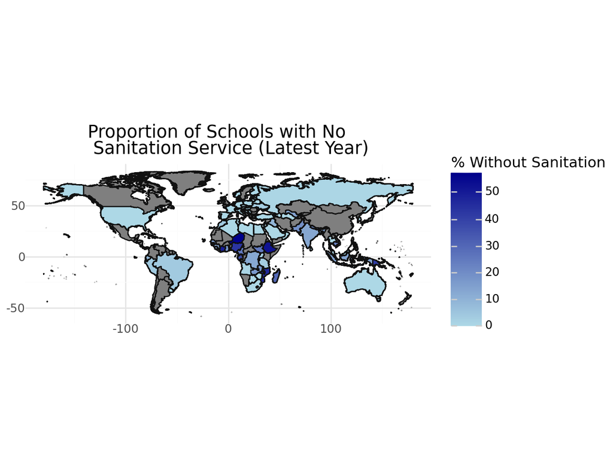

```python
# Load world shape
world = gpd.read_file("https://public.opendatasoft.com/api/explore/v2.1/catalog/datasets/world-administrative-boundaries/exports/shp")

# Identify correct ISO column in world data
iso_column = next((col for col in world.columns if 'iso' in col.lower() and '3' in col.lower()), None)

# Merge map with data if column exists
if iso_column:
    map_data = world.merge(combined_pd, left_on=iso_column, right_on="alpha_3_code", how="left")

    # ✅ Plot with draw + show for Colab
    p = (
        ggplot(map_data)
        + aes(fill='obs_value')
        + geom_map()
        + scale_fill_gradient(low='lightblue', high='darkblue')
        + labs(title='Proportion of Schools with No\n Sanitation Service (Latest Year)', fill='% Without Sanitation')
        + coord_fixed()
        + theme_minimal()
    )
    p.draw()
    p.show()
else:
    print("ISO3 column not found in shapefile. Please check column names in `world.columns`.")
```

# Countries Most Affected

## Bar Graph

To understand the countries most affected, we examine the top 10 with the highest lack of school sanitation.

```python
import matplotlib.pyplot as plt

# Top 10 worst countries based only on sanitation data
worst_10 = (
    indicator_latest
    .to_pandas()
    .sort_values(by='obs_value', ascending=False)
    .head(10)
)


p = (
    ggplot(worst_10)
    + aes(x='reorder(country, obs_value)', y='obs_value', fill='country')
    + geom_col(show_legend=False)
    + coord_flip()
    + labs(x='Country', y='% Schools without Sanitation', title='Top 10 Countries with Poorest School Sanitation')
    + theme_light()
)
```

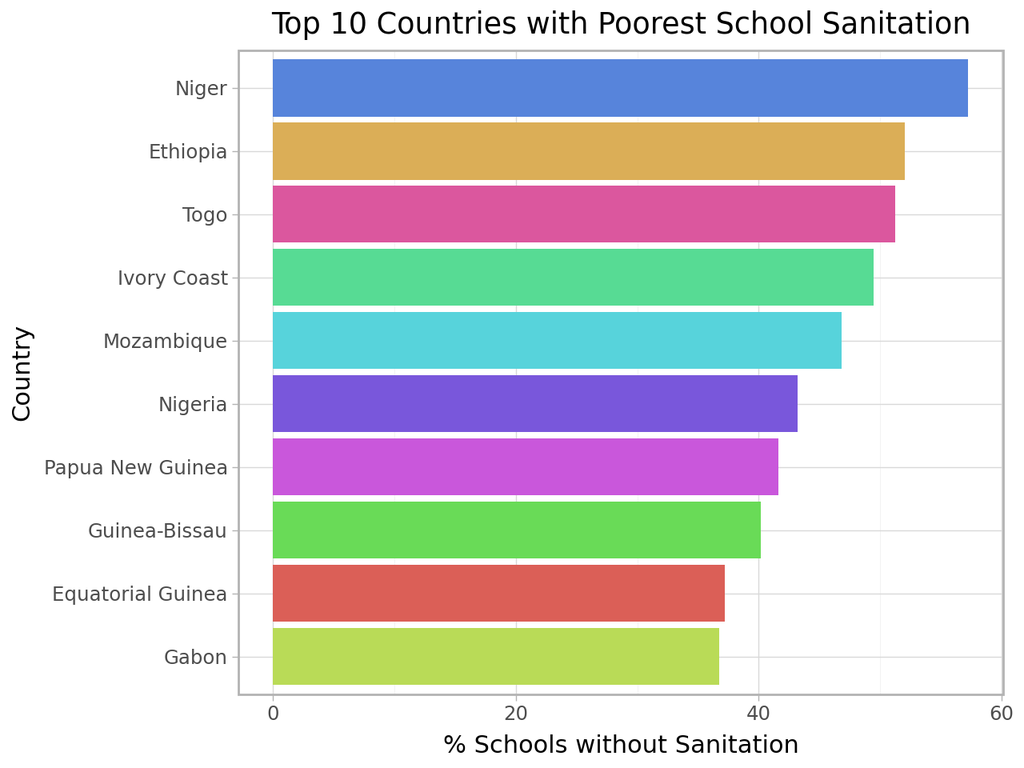

```python
import matplotlib.pyplot as plt

p = (
    ggplot(worst_10)
    + aes(x='reorder(country, obs_value)', y='obs_value', fill='country')
    + geom_col(show_legend=False)
    + coord_flip()
    + labs(x='Country', y='% Schools without Sanitation', title='Top 10 Countries with Poorest School Sanitation')
    + theme_light()
)
p.draw()
p.show()
```

# GDP vs Lack of School Sanitation

We now explore the relationship between a country’s wealth and access to sanitation services.

```python
combined_pd = combined_pd.rename(columns={
    'GDP per capita (constant 2015 US$)': 'gdp_per_capita',
    'obs_value': 'sanitation_percent'
})
```

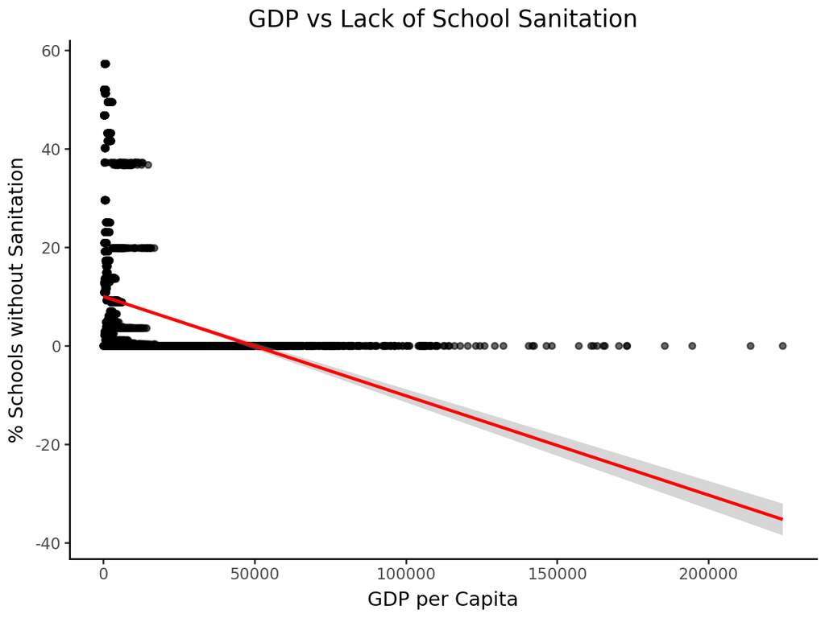

```python
p = (
    ggplot(combined_pd)
    + aes(x='gdp_per_capita', y='sanitation_percent') # Use the renamed column names
    + geom_point(alpha=0.6)
    + geom_smooth(method='lm', color='red')
    + labs(x='GDP per Capita', y='% Schools without Sanitation', title='GDP vs Lack of School Sanitation')
    + theme_classic()
)
p.draw()
p.show()
```

# Global Progress on School Sanitation

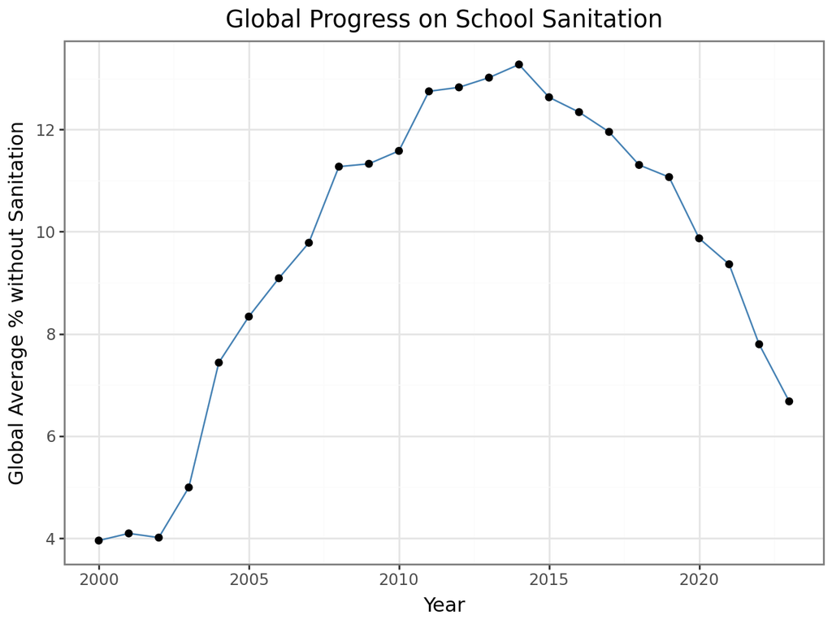

```python
trend = (indicator
    .group_by("time_period")
    .agg(pl.col("obs_value").mean().alias("global_avg"))
    .to_pandas()
)

p = (
    ggplot(trend)
    + aes(x='time_period', y='global_avg')
    + geom_line(color='steelblue')
    + geom_point()
    + labs(x='Year', y='Global Average % without Sanitation', title='Global Progress on School Sanitation')
    + theme_bw()
)
p.show()
```

# Conclusion

School sanitation is not just a health issue — it is directly tied to educational access, gender equality, and social dignity. Our analysis shows that economic development plays a major role in improving sanitation facilities, but global disparities remain alarming.

Investments in school sanitation must be prioritized urgently, particularly in the most vulnerable regions. Without safe toilets, the goals of universal education and gender equality cannot be achieved.